# New Hanover Township — NJ School Data Almanac – NJ District Profiles

NJ School Data Almanac

New Hanover Township

BURLINGTON COUNTY · TRADITIONAL PUBLIC DISTRICT · DFG B · 219 STUDENTS (2026)

219

Students

28.3%

Gr 3-8 ELA

19.2%

Chronically absent

$19,502

Per pupil

*8 things the data says about New Hanover Township. Every figure is computed from New Jersey Department of Education data via the njschooldata package — nothing is estimated. Comparisons use District Factor Group (DFG) peers (67 districts in DFG B).*

No. 1 ACHIEVEMENT

## New Hanover Reading Proficiency Crashed 26 Points After COVID and Still Sits at 28%

Just 28.3% of New Hanover’s grades 3-8 students were proficient in English in 2024, down from 53.1% in 2019 and barely above the pandemic low.

Before the pandemic, more than half of New Hanover Township’s grades 3-8 students could read at grade level: 53.1% scored proficient on the 2019 NJSLA English test. Then the floor gave way. By 2022, the first post-shutdown testing year, proficiency had collapsed to 26.7%, a 26.4-point drop that wiped out roughly half of the district’s readers.

The recovery has been faint. ELA proficiency edged to 30.4% in 2023 before slipping back to 28.3% in 2024, still 25 points below where the district stood in 2019 and essentially flat against its pandemic trough. Math tells a similar story: proficiency fell from 36.7% in 2019 to 14.9% in 2022, then climbed only partway back to 23.4% by 2024.

For a K-8 district whose entire job is to build foundational skills before students move on to high school elsewhere, two consecutive cohorts testing near or below 30% in reading is a flashing signal. The numbers raise a question the data cannot answer: are these the lingering scars of lost instructional time, or a new baseline that recovery efforts have yet to move?

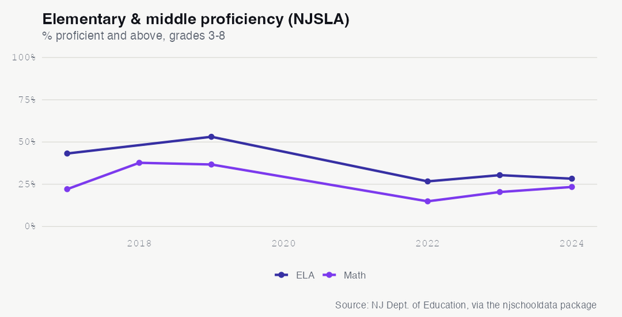

See the underlying data ›

No. 2 ENROLLMENT

## New Hanover’s Enrollment Jumped 18% in a Single Year to a Record 219 Students

After a decade bouncing between 166 and 192 students, the tiny Burlington County K-8 district added 34 children in 2026 to hit its largest count on record.

For most of the past decade, New Hanover Township ran a small, slowly fluctuating school system. Enrollment slid from 183 students in 2015 to a pandemic low of 166 in 2021, then drifted in the 180s for several years. In 2026 it leaped: 219 students, up 34 from the prior year, an 18.4% jump in a single fall and the largest one-year swing in the available record.

That surge pushed total enrollment to its peak. Compared with 2015, the district now serves 36 more students, a 19.7% gain over the period. In a district this small, near Joint Base McGuire-Dix-Lakehurst and serving a military-connected community, a swing of a few dozen families can reshape an entire grade.

The COVID years account for some movement: enrollment dipped to 166 in 2021 before recovering to 182 by 2022, a net 5.2% gain from 2019. But the 2026 jump dwarfs that rebound. What is driving the sudden influx, and can a district built around fewer than 200 students staff and house a class that just grew this fast?

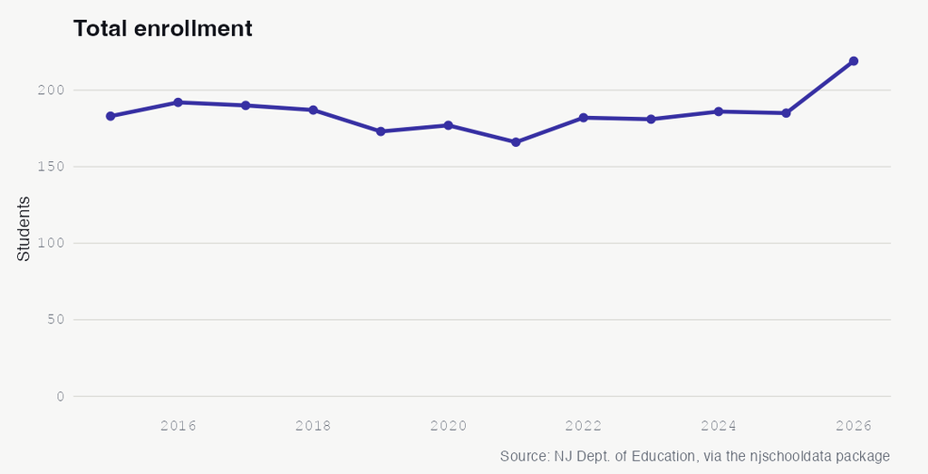

See the underlying data ›

No. 3 EQUITY

## In New Hanover, Hispanic Students Outscore White Students in Reading, 30% to 27%

On the 2024 NJSLA, the district’s economic divide outweighed its racial one: students who are not economically disadvantaged passed at 28.6% versus 20.0% for those who are.

Achievement gaps in New Hanover Township do not follow the usual script. On the 2024 grades 3-8 English test, Hispanic students posted the highest proficiency rate of any reported group at 30.0%, edging out white students at 27.3% and the district average of 28.3%. The familiar racial gap in reading simply does not appear in these numbers.

The sharper divide is economic. Students who are not economically disadvantaged passed at 28.6%, while students who are economically disadvantaged passed at 20.0%, an 8.6-point gap. In a district where a majority of children now qualify for subsidized lunch, that is the line that separates who is reading at grade level and who is not.

Results by gender were suppressed, a common outcome in a district testing only a few dozen children per grade. But the pattern that does show through, income mattering more than race, points the district’s attention toward its growing population of students from lower-income families. Can targeted support close an 8.6-point gap when the families on the wrong side of it are a rising share of the school?

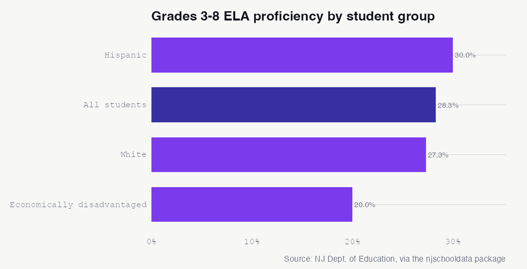

See the underlying data ›

No. 4 DEMOGRAPHICS

## Majority of New Hanover Students Now Qualify for Subsidized Lunch, Up From 43% in 2015

Economic need has deepened in New Hanover Township over the past decade. In 2015, 79 students, or 43.2%, qualified for free or reduced-price lunch. By 2026, that figure had climbed to 115 students, or 52.6%, meaning a majority of the district’s children now come from families that meet the income threshold for subsidized meals.

That a small, military-adjacent district has tipped to majority economically disadvantaged matters for how it budgets meals, staffing, and academic support, especially given that these are the students testing lowest in reading. As enrollment and need both climb, will the district’s per-pupil resources keep pace with the families now walking through its doors?

See the underlying data ›

No. 5 ATTENDANCE

## Nearly 1 in 5 New Hanover Students Were Chronically Absent in 2024, Almost Double the Pre-COVID Rate

Chronic absenteeism reached 19.2% in 2024, up from 10.3% in 2019 and edging just above the district’s DFG B peer median.

Before the pandemic, New Hanover Township kept most of its students in their seats: 10.3% were chronically absent in 2019, meaning they missed at least 10% of the school year. By 2024, that rate had nearly doubled to 19.2%, leaving roughly one in five students at risk of falling behind from missed instruction alone.

The spike was sharpest right after schools reopened. Chronic absenteeism climbed to 14.3% in 2021 and peaked at 20.1% in 2022 before easing to 17.1% in 2023, then rising again to 19.2%. The 2024 figure sits just above the median of 18.3% for districts in New Hanover’s District Factor Group B peer group, so the district is not an outlier among similar communities, but it has not returned to its own pre-COVID baseline either.

The absence story shadows the test-score story: missed days and stalled reading recovery tend to travel together. For a K-8 district where early attendance habits set the foundation for later years, the gap between 10.3% and 19.2% represents a meaningful share of young students missing weeks of school. What will it take to pull the rate back toward where it stood before 2020?

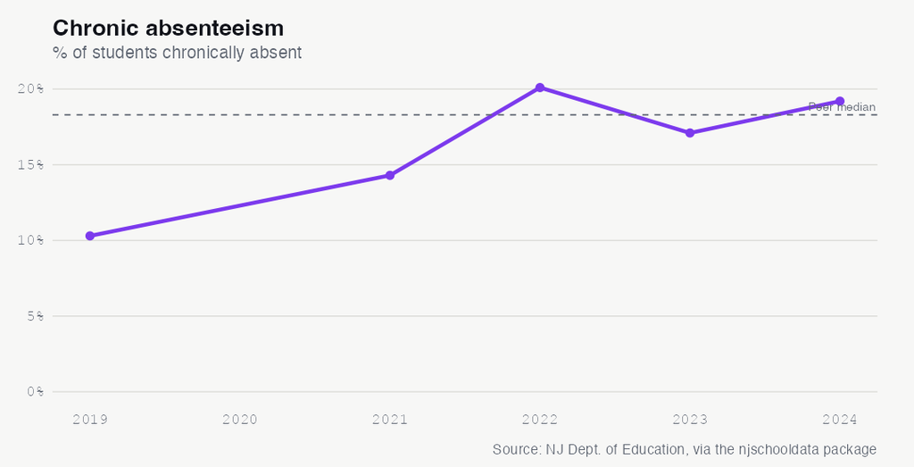

See the underlying data ›

No. 6 FINANCE

## New Hanover’s Spending Rank Among 67 Peers Climbed From 64th to 23rd as Per-Pupil Costs Fell

Per-pupil spending dropped from a 2019 peak of $22,655 to $19,502 in 2024, yet the district moved up the DFG B spending ranks as peers’ costs rose faster.

New Hanover Township spent $19,502 per pupil in 2024, placing it at the 71st percentile among its 67 District Factor Group B peers, above the peer median of $18,001. But the more telling story is the trajectory. The district’s per-pupil spending actually fell from a 2019 peak of $22,655 to a low of $18,344 in 2023 before ticking back up.

Even as its own spending declined, New Hanover climbed the relative ranks: from 64th among peers in 2014 to 23rd in 2024. In other words, the district grew comparatively more expensive not by spending more, but by cutting less than the communities around it. Since 2014, its per-pupil figure rose just 2.4%, a modest increase over a decade of inflation.

Of every dollar spent in 2025, 59.7% went to the classroom, with 18.6% to support services, 11.9% to plant operations, and 8.2% to administration. As enrollment surges and reading scores lag, will the district’s spending follow the students into the supports they need, or will fixed costs in a very small system stretch each dollar thinner?

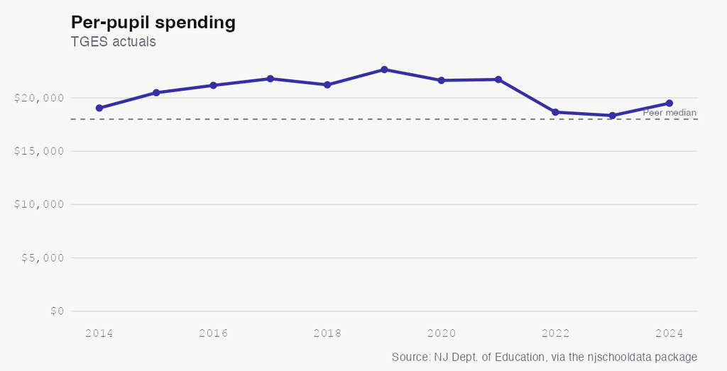

See the underlying data ›

No. 7 DEMOGRAPHICS

## New Hanover’s Black Enrollment Share Fell From 19.7% to 14.6% as White Share Rose to 42.5%

New Hanover Township’s student body has reshaped itself over the past decade. The Black share of enrollment fell from 19.7% in 2015 to 14.6% in 2026, a drop of 5.1 percentage points and the largest single demographic change in the district. Over the same period the white share rose from 37.7% to 42.5%, a gain of 4.8 points, and the Hispanic share edged up 2.1 points to 39.3%.

One quieter shift sits in the multiracial category, which swelled to 12.0% of students in 2021 before falling back to 3.2% by 2026, a reminder that in a district of barely 200 children, a handful of families can move the percentages sharply. As the district’s enrollment surges, will these trends hold or reverse with the newest arrivals?

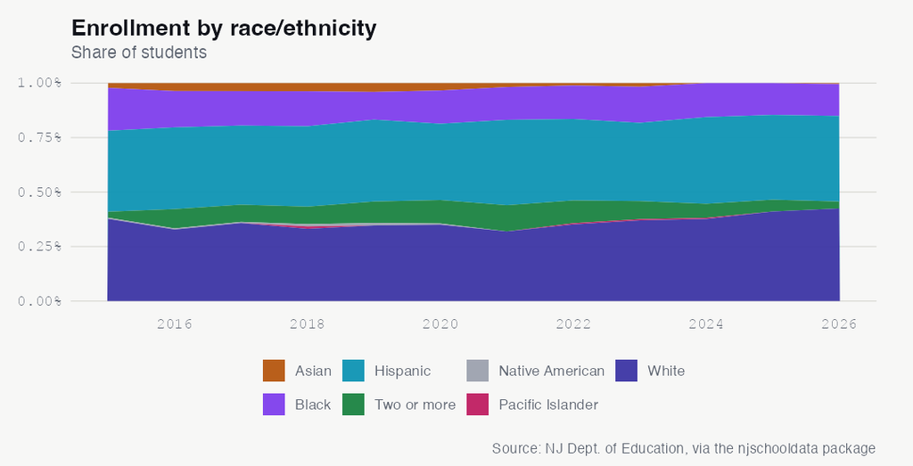

See the underlying data ›

No. 8 DEMOGRAPHICS

## New Hanover’s English-Learner Share Fell by More Than Half, From 21.4% in 2019 to 6.8% in 2026

The number of students classified as English learners dropped from a peak of 38 to just 15, even as overall enrollment hit a record high.

Fewer English learners can ease classroom demands, but it also reflects who is and is not enrolling. In a district adding students fast, will the newest arrivals reverse this decade-long slide, or has New Hanover’s language-services population settled at a new, lower baseline?

See the underlying data ›

## The Almanac

The full longitudinal record behind the stories above. Every number a reader can check.

### Enrollment (total)

| year | students | yoy | yoy_pct |
| --- | --- | --- | --- |
| 2015 | 183 | NA | NA |
| 2016 | 192 | 9 | 4.9 |
| 2017 | 190 | -2 | -1 |
| 2018 | 187 | -3 | -1.6 |
| 2019 | 173 | -14 | -7.5 |
| 2020 | 177 | 4 | 2.3 |
| 2021 | 166 | -11 | -6.2 |
| 2022 | 182 | 16 | 9.6 |
| 2023 | 181 | -1 | -0.5 |
| 2024 | 186 | 5 | 2.8 |
| 2025 | 185 | -1 | -0.5 |
| 2026 | 219 | 34 | 18.4 |

### Demographic share (%) by year

| end_year | white | black | hispanic | asian | native_american | pacific_islander | multiracial |
| --- | --- | --- | --- | --- | --- | --- | --- |
| 2015 | 37.7 | 19.7 | 37.2 | 2.2 | 0.5 | 0 | 2.7 |
| 2016 | 32.8 | 16.7 | 37.5 | 3.6 | 0.5 | 0 | 8.9 |
| 2017 | 35.8 | 15.8 | 36.3 | 3.7 | 0.5 | 0 | 7.9 |
| 2018 | 33.2 | 16 | 36.9 | 3.7 | 1.1 | 1.1 | 8 |
| 2019 | 34.7 | 12.7 | 37.6 | 4 | 1.2 | 0 | 9.8 |
| 2020 | 35 | 15.3 | 35 | 3.4 | 0.6 | 0 | 10.7 |
| 2021 | 31.9 | 15.1 | 39.2 | 1.8 | 0 | 0 | 12 |
| 2022 | 35.2 | 15.4 | 37.4 | 1.1 | 0 | 0.5 | 10.4 |
| 2023 | 37 | 16.6 | 35.9 | 1.7 | 0 | 0.6 | 8.3 |
| 2024 | 37.6 | 15.6 | 39.8 | 0 | 0 | 0.5 | 6.5 |
| 2025 | 41.1 | 14.6 | 38.9 | 0 | 0 | 0 | 5.4 |
| 2026 | 42.5 | 14.6 | 39.3 | 0.5 | 0 | 0 | 3.2 |

### Special populations (LEP, FRL)

| end_year | subgroup | students | pct |
| --- | --- | --- | --- |
| 2015 | lep | 24 | 13.1 |
| 2015 | free_reduced_lunch | 79 | 43.2 |
| 2016 | lep | 32 | 16.7 |
| 2016 | free_reduced_lunch | 87 | 45.3 |
| 2017 | lep | 33 | 17.4 |
| 2017 | free_reduced_lunch | 85 | 44.7 |
| 2018 | lep | 38 | 20.3 |
| 2018 | free_reduced_lunch | 84 | 44.9 |
| 2019 | lep | 37 | 21.4 |
| 2019 | free_reduced_lunch | 74 | 42.8 |
| 2020 | lep | 23 | 13.0 |
| 2020 | free_reduced_lunch | 103 | 58.2 |
| 2021 | lep | 23 | 13.9 |
| 2021 | free_reduced_lunch | 86 | 51.8 |
| 2022 | lep | 24 | 13.2 |
| 2022 | free_reduced_lunch | 87 | 47.8 |
| 2023 | lep | 21 | 11.6 |
| 2023 | free_reduced_lunch | 89 | 49.1 |
| 2024 | lep | 19 | 10.2 |
| 2024 | free_reduced_lunch | 91 | 48.9 |
| 2025 | lep | 17 | 9.2 |
| 2025 | free_reduced_lunch | 97 | 52.5 |
| 2026 | lep | 15 | 6.8 |
| 2026 | free_reduced_lunch | 115 | 52.6 |

### NJSLA grades 3-8 proficiency (% proficient+, enrollment-weighted across grades)

| testing_year | test_name | prof |
| --- | --- | --- |
| 2017 | ela | 43.2 |
| 2017 | math | 22.1 |
| 2018 | math | 37.7 |
| 2019 | ela | 53.1 |
| 2019 | math | 36.7 |
| 2022 | ela | 26.7 |
| 2022 | math | 14.9 |
| 2023 | ela | 30.4 |
| 2023 | math | 20.4 |
| 2024 | ela | 28.3 |
| 2024 | math | 23.4 |

### NJSLA ELA proficiency by subgroup (2024, grades 3-8)

| subgroup | prof |
| --- | --- |
| hispanic | 30.0 |
| non_ed | 28.6 |
| total_population | 28.3 |
| white | 27.3 |
| ed | 20.0 |
| female | NA |
| male | NA |

### Chronic absenteeism (% chronically absent)

| year | chronic_pct |
| --- | --- |
| 2019 | 10.3 |
| 2021 | 14.3 |
| 2022 | 20.1 |
| 2023 | 17.1 |
| 2024 | 19.2 |

### Disciplinary removals

[output not shown]

### Police notifications (incident counts)

| year | violence | weapons | vandalism | substances | hib | other |
| --- | --- | --- | --- | --- | --- | --- |
| 2019 | 0 | 0 | 0 | 0 | 0 | 0 |
| 2020 | 0 | 0 | 0 | 0 | 0 | 0 |
| 2021 | 0 | 0 | 0 | 0 | 0 | 0 |
| 2022 | 0 | 0 | 0 | 0 | 0 | 0 |
| 2023 | 2 | 0 | 1 | 0 | 0 | 0 |
| 2024 | 0 | 0 | 0 | 0 | 0 | 0 |

### HIB (harassment/intimidation/bullying) investigations

| end_year | alleged | confirmed |
| --- | --- | --- |
| 2019 | 6 | 2 |
| 2020 | 11 | 2 |
| 2021 | 2 | 1 |
| 2022 | 1 | 1 |
| 2023 | 13 | 1 |
| 2024 | 6 | 0 |

### Special education (raw rows; inspect for classification rate)

| end_year | district_id |
| --- | --- |
| 2024 | 3540 |

### Per-pupil spending (TGES actuals)

| year | per_pupil | rank | ade |
| --- | --- | --- | --- |
| 2014 | 19048 | 64 | 188 |
| 2015 | 20489 | 66 | 186 |
| 2016 | 21171 | 64 | 187 |
| 2017 | 21798 | 65 | 186 |
| 2018 | 21222 | 59 | 188 |
| 2019 | 22655 | 64 | 170 |
| 2020 | 21638 | 64 | 175 |
| 2021 | 21725 | 54 | 168 |
| 2022 | 18660 | 32 | 185 |
| 2023 | 18344 | 26 | 179 |
| 2024 | 19502 | 23 | 185 |

### Spending composition shares (2025)

| classroom_share | support_services_share | administration_share | plant_ops_share | food_service_share | extracurricular_share | equipment_share |
| --- | --- | --- | --- | --- | --- | --- |
| 59.7 | 18.6 | 8.2 | 11.9 | NA | 1.2 | 0 |

### Staffing ratios

| end_year | student_teacher_district | student_admin_district | student_counselor_district | student_nurse_district |
| --- | --- | --- | --- | --- |
| 2024 | 9:1 | 62:1 | NA | 186:1 |

Back to top